# urlTables

May 7, 2017

# Downloading Tables from the Internet

Since I use it so much, I figure it would be useful to others. I call it `urlTables`. It’s just some code from `rvest` packaged into a little function. You will be able grab a lot of data online easily. This is one of those functions I find myself using over and over.

If you don’t have `rvest` install it now!

```r
install.packages("rvest")
```

```r
library(rvest)
```

# The Function

```r
urlTables = function (url, ...) {
  website <- read_html(url)
  list <- website %>% html_table(...)
  list
}
```

# Grab Treasuries from WSJ

Let’s check it out! It won’t always work. Also, if it asks “do you want to fill” then change `fill = FALSE` to `fill = TRUE` You may get multple lists back so be sure to “look” through the list.

```r
treasuries = urlTables("http://online.wsj.com/mdc/public/page/2_3020-treasury.html", fill = FALSE)
```

Let’s pull the treasury data and then convert the dataframe into something we can plot! Here, there is a minor inconvenience because the first row contains the column names. I just remove them.

```r
treasuries[[3]] %>%
  head()
```

```
##          X1     X2       X3       X4      X5         X6
## 1  Maturity Coupon      Bid    Asked     Chg Askedyield
## 2 5/15/2017  0.875  99.9844 100.0000 -0.0234      0.873
## 3 5/15/2017  4.500 100.0547 100.0703 -0.0313      0.847
## 4 5/15/2017  8.750 100.1094 100.1250 -0.0547      2.202
## 5 5/31/2017  0.625  99.9844 100.0000   unch.      0.624
## 6 5/31/2017  2.750 100.1094 100.1250 -0.0156      0.763
```

```r
date = treasuries[[3]][,1]
date = as.Date(date[-1], "%m/%d/%Y")
yld = treasuries[[3]][,6]
yld = as.numeric(yld[-1])
df = data.frame(date = date, askedYld = yld)
```

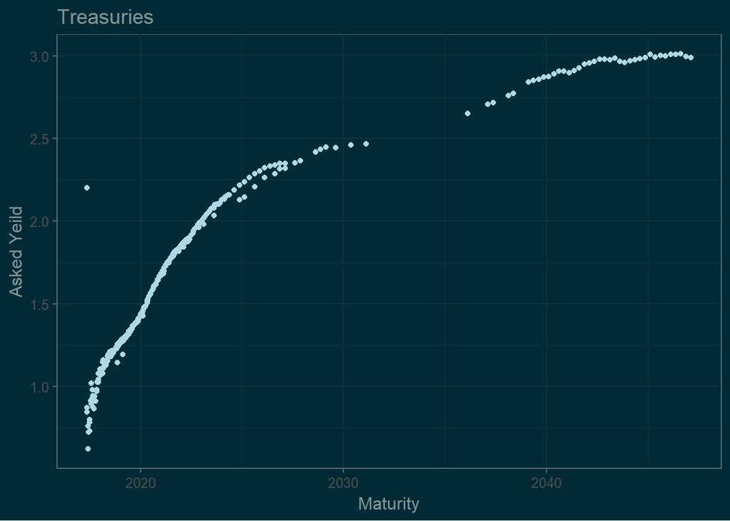

```r
library(ggplot2)
library(ggthemes)
ggplot(df, aes(x = date, y = yld)) +
  geom_point(col = "light blue") +
  theme_solarized(light = FALSE) +
  xlab("Maturity") +
  ylab("Asked Yeild") +
  ggtitle("Treasuries")
```

# Get the S&P

Ok, what else is there? We can download tables with Wikipedia! If it’s on the internet and it looks like a table, try and grab it with this function!

```r
snp = urlTables("https://en.wikipedia.org/wiki/List_of_S%26P_500_companies", fill = TRUE)
snp = snp[[1]]
head(snp)
```

```
##   Ticker symbol            Security SEC filings            GICS Sector
## 1           MMM          3M Company     reports            Industrials
## 2           ABT Abbott Laboratories     reports            Health Care
## 3          ABBV         AbbVie Inc.     reports            Health Care
## 4           ACN       Accenture plc     reports Information Technology
## 5          ATVI Activision Blizzard     reports Information Technology
## 6           AYI   Acuity Brands Inc     reports            Industrials
##                   GICS Sub Industry  Address of Headquarters
## 1          Industrial Conglomerates      St. Paul, Minnesota
## 2             Health Care Equipment  North Chicago, Illinois
## 3                   Pharmaceuticals  North Chicago, Illinois
## 4    IT Consulting & Other Services          Dublin, Ireland
## 5       Home Entertainment Software Santa Monica, California
## 6 Electrical Components & Equipment         Atlanta, Georgia
##   Date first added     CIK
## 1                    66740
## 2       1964-03-31    1800
## 3       2012-12-31 1551152
## 4       2011-07-06 1467373
## 5       2015-08-31  718877
## 6       2016-05-03 1144215
```

Now, we can download the entire S&P 500 into `quantmod`… or not. : )

```r
tickers = snp[,1]
tickers
```

```
##   [1] "MMM"   "ABT"   "ABBV"  "ACN"   "ATVI"  "AYI"   "ADBE"  "AMD"
##   [9] "AAP"   "AES"   "AET"   "AMG"   "AFL"   "A"     "APD"   "AKAM"
##  [17] "ALK"   "ALB"   "ARE"   "AGN"   "LNT"   "ALXN"  "ALLE"  "ADS"
##  [25] "ALL"   "GOOGL" "GOOG"  "MO"    "AMZN"  "AEE"   "AAL"   "AEP"
##  [33] "AXP"   "AIG"   "AMT"   "AWK"   "AMP"   "ABC"   "AME"   "AMGN"
##  [41] "APH"   "APC"   "ADI"   "ANTM"  "AON"   "APA"   "AIV"   "AAPL"
##  [49] "AMAT"  "ADM"   "ARNC"  "AJG"   "AIZ"   "T"     "ADSK"  "ADP"
##  [57] "AN"    "AZO"   "AVB"   "AVY"   "BHI"   "BLL"   "BAC"   "BK"
##  [65] "BCR"   "BAX"   "BBT"   "BDX"   "BBBY"  "BRK.B" "BBY"   "BIIB"
##  [73] "BLK"   "HRB"   "BA"    "BWA"   "BXP"   "BSX"   "BMY"   "AVGO"
##  [81] "BF.B"  "CHRW"  "CA"    "COG"   "CPB"   "COF"   "CAH"   "CBOE"
##  [89] "KMX"   "CCL"   "CAT"   "CBG"   "CBS"   "CELG"  "CNC"   "CNP"
##  [97] "CTL"   "CERN"  "CF"    "SCHW"  "CHTR"  "CHK"   "CVX"   "CMG"
## [105] "CB"    "CHD"   "CI"    "XEC"   "CINF"  "CTAS"  "CSCO"  "C"
## [113] "CFG"   "CTXS"  "CLX"   "CME"   "CMS"   "COH"   "KO"    "CTSH"
```

[output cut: 49 more lines]

```r
library(quantmod)

getTicks = tickers[1:5]
getSymbols(getTicks)
```

```
## [1] "MMM"  "ABT"  "ABBV" "ACN"  "ATVI"
```

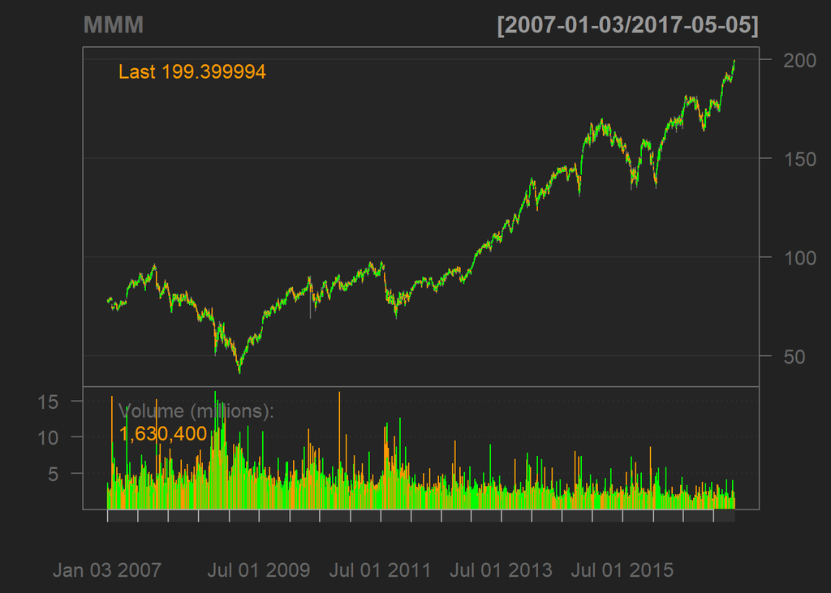

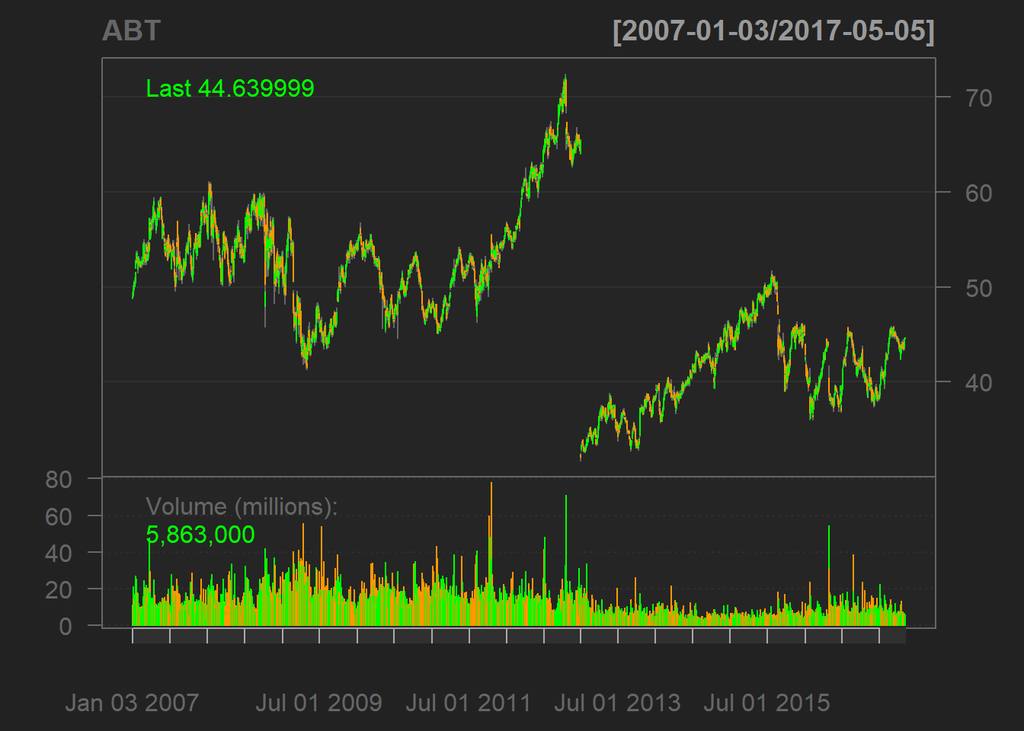

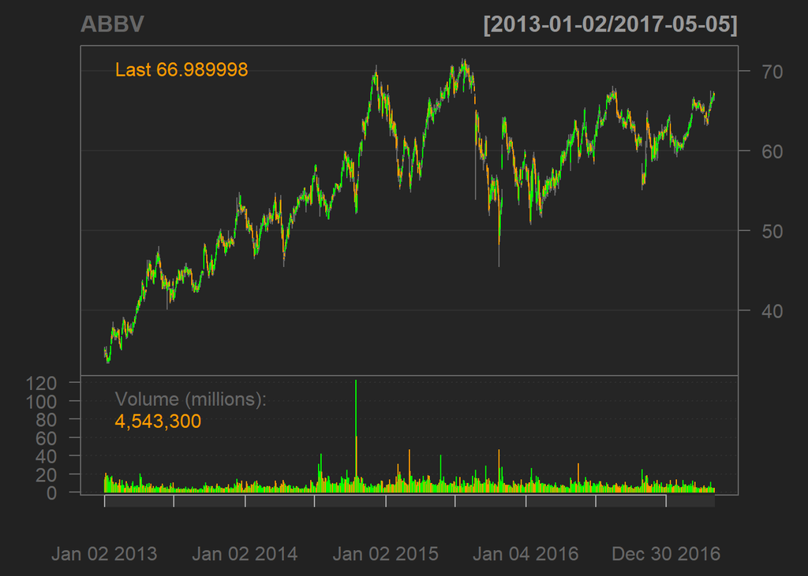

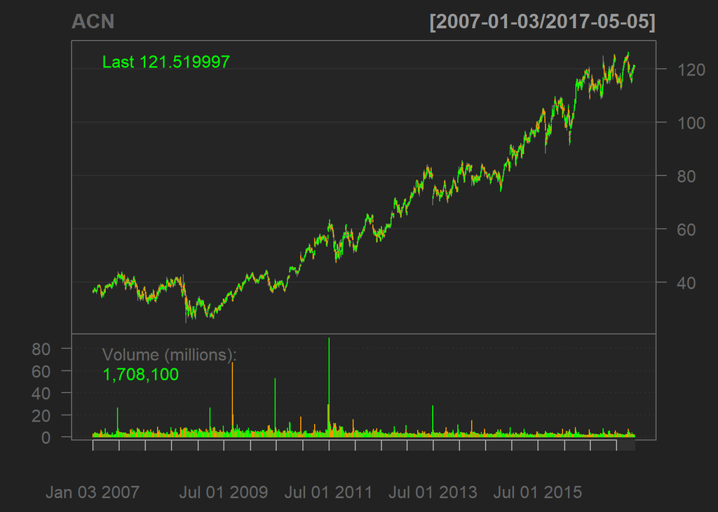

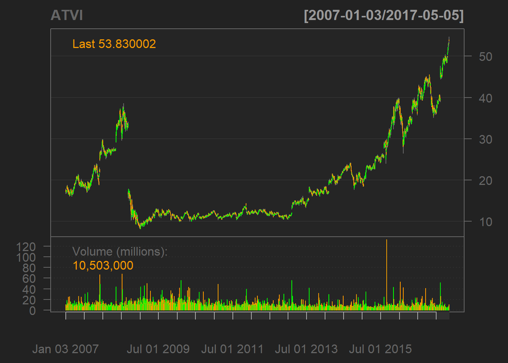

```r
for(i in 1:length(getTicks)) {
  chartSeries(get(getTicks[i]), name = getTicks[i])
}
```

# Imports by Country

```r
imports = urlTables("https://en.wikipedia.org/wiki/List_of_countries_by_imports", fill = TRUE)
imports = imports[[2]][,2:3]

head(imports)
```

```
##                                     COUNTRY            IMPORTS
## 1 European Union (excluding intra-EU trade) $2,244,000,000,000
## 2                             United States $2,205,000,000,000
## 3                                     China $1,437,000,000,000
## 4                                   Germany   $987,600,000,000
## 5                                     Japan   $629,800,000,000
## 6                            United Kingdom   $581,600,000,000
```

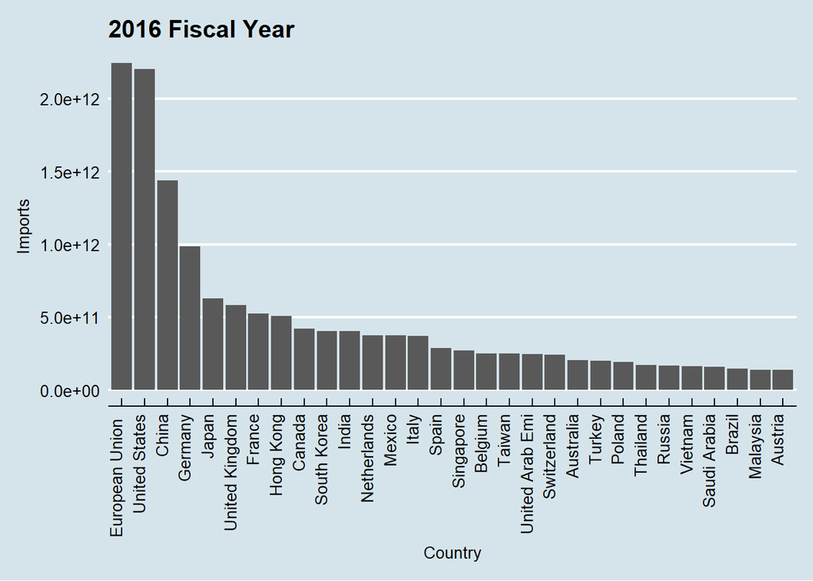

```r
imports$COUNTRY = substr(imports$COUNTRY, start = 1, stop = 15)
imports$IMPORTS = gsub(",", "", imports$IMPORTS)
imports$IMPORTS = as.numeric(sub("\\$", "", imports$IMPORTS))

imports = imports[1:30,]
ggbar = ggplot(imports, aes(x=reorder(COUNTRY, -IMPORTS), y = IMPORTS)) +
     geom_bar(stat = "identity") +
     xlab("Country") +
     ylab("Imports") +
     ggtitle("2016 Fiscal Year") +
     theme_economist() +
     theme(axis.text.x = element_text(angle = 90, hjust = 1))
ggbar
```

I hope this is useful to you in the future!